# Crime in Los Angeles from 2010-2019

Yanhong Han

2019-05-01

###1. Executive Summary  
####1.1 Dataset In this project, I am analyzing the crime incidents that committed in Los Angeles, California from 2010 to 2019 (present). The dataset can be downloaded from https://data.lacity.org/A-Safe-City/Crime-Data-from-2010-to-Present/y8tr-7khq. The original data set contains 1942338 observations and 26 variables.

####1.2 Goal  
My goal is to analyze the dataset and give the readers some ideas about which locations or time period crimes occurred most frequently, which age/race/gender are the most dangerous victim groups, if there are trends existed in crimes, etc.

####1.3 Assumptions  
In the dataset, the victim ages range from negative numbers to 99 years old. I assume the victims are all individuals from 1 year old to 99 years old.

12am is the time period most of the crimes committed, especially for theft crimes. 5am is the time period least of the crimes committed.

People aged from 25 to 50 years old is the group that most likely to be targeted as a victim. The average age of the female victims is lower than that of male victims which means young women are more likely to be targeted.

Female Black/African American or Hispanic/Latino are more likely to be targeted than male in their own race group. The opposite for Native Hawaiian/Other Pacific Islaner or White race group.

For female, intimate partner-simple assault is an important crime type committed to them especially in single family dwelling or multiunit dwellings.

####1.6 Out of Scope  
The dataset only contains crime data that the crimes have occurred in this district. The information of the total number of residents, the distribution of the race/age/gender of total residents are not included in the dataset. Therefore, the analysis of this project is based on crimes have committed, the relative crime rate of each race/age/gender is not included in this report.

**Dataset Structure**

```
Classes data.table and 'data.frame':  1942338 obs. of  26 variables:
 $ DR Number             : int  110215293 110215294 110215295 110215296 110215299 110215301 110215302 110215304 110215306 110215311 ...
 $ Date Reported         : chr  "08/08/2011" "08/08/2011" "08/08/2011" "08/08/2011" ...
 $ Date Occurred         : chr  "08/08/2011" "07/30/2011" "08/02/2011" "08/08/2011" ...
 $ Time Occurred         : int  1700 5 1430 1810 1800 2250 2320 840 2350 1800 ...
 $ Area ID               : int  2 2 2 2 2 2 2 2 2 2 ...
 $ Area Name             : chr  "Rampart" "Rampart" "Rampart" "Rampart" ...
 $ Reporting District    : int  256 231 231 257 299 299 241 233 299 217 ...
 $ Crime Code            : int  930 956 956 901 440 626 745 310 510 310 ...
 $ Crime Code Description: chr  "CRIMINAL THREATS - NO WEAPON DISPLAYED" "LETTERS, LEWD  -  TELEPHONE CALLS, LEWD" "LETTERS, LEWD  -  TELEPHONE CALLS, LEWD" "VIOLATION OF RESTRAINING ORDER" ...
 $ MO Codes              : chr  "0421 0432 0444 0601 0913" "1820" "1814 2000" "1814 2000" ...
 $ Victim Age            : int  57 20 43 22 0 23 25 56 0 68 ...
 $ Victim Sex            : chr  "F" "F" "M" "F" ...
 $ Victim Descent        : chr  "A" "B" "B" "H" ...
 $ Premise Code          : int  203 502 502 203 102 501 122 502 101 501 ...
 $ Premise Description   : chr  "OTHER BUSINESS" "MULTI-UNIT DWELLING (APARTMENT, DUPLEX, ETC)" "MULTI-UNIT DWELLING (APARTMENT, DUPLEX, ETC)" "OTHER BUSINESS" ...
 $ Weapon Used Code      : int  511 NA NA NA 400 400 NA NA NA NA ...
 $ Weapon Description    : chr  "VERBAL THREAT" "" "" "" ...
 $ Status Code           : chr  "AO" "IC" "AO" "AO" ...
 $ Status Description    : chr  "Adult Other" "Invest Cont" "Adult Other" "Adult Other" ...
 $ Crime Code 1          : int  930 956 956 901 440 626 745 310 510 310 ...
 $ Crime Code 2          : int  NA NA NA NA NA NA NA NA NA NA ...
 $ Crime Code 3          : int  NA NA NA NA NA NA NA NA NA NA ...
 $ Crime Code 4          : int  NA NA NA NA NA NA NA NA NA NA ...
 $ Address               : chr  "1800    WILSHIRE                     BL" "100 N  OCCIDENTAL                   BL" "100 S  DILLON                       ST" "1200    WILSHIRE                     BL" ...
 $ Cross Street          : chr  "" "" "" "" ...
 $ Location              : chr  "(34.0564, -118.2725)" "(34.0707, -118.2795)" "(34.0723, -118.2831)" "(34.053, -118.2648)" ...
 - attr(*, ".internal.selfref")=<externalptr>
```

###2. Dataset Cleansing  
####2.1 Remove missing values  
In the dataset, columns (MO Codes,Weapon Used Code,Weapon Description,Crime Code 2-4,Cross Stree) have more than 90% of the missing values, those columns will not contribute too much for the analysis, so I removed those variables. Then the missing values are removed as well.

####2.2 Remove duplicate variable  
Variable ‘Crime Code’ and ‘Crime Code 1’ have 99% of the same values, so I omitted the rows that have different values, and removed variable ‘Crime Code 1’ after removing the different values.

*— Table of the different crime code count (0 represent different, 1 represent same)*

```
      0       1
   2962 1757436
```

####2.3 Create new variable Latitude and Longitude  
The Location variable is seperated into variables Longitude and Latitude. The two variables are used to plot map or make prediction in later analysis.

####2.4 Manipulate data type  
The variables are converted into appropriate data type.

- The column ‘DR_Number’ contains unformatted values, the values should be formatted as ‘yy-aa-xxxxx’ (yy - 2 digit year, aa - 2 area code, xxxxx - 5 digits). e.g. 100112345
- Convert ‘TimeOccurred’ into 24-hour time range
- Convert categorical variables into factors
- Victims whose gender are neither Female nor Male are categorized as ‘Unknown’
- Victim race are categorized into 7 common race groups
- Convert latitude and longtitude into continuous variables
- Remove the observations with victim ages smaller than 0

####2.5 Create new variables  
**CrimeCategory Variable**  
There are 138 levels of crime codes in the originally dataset. While exploring the dataset, I found some of the crimes are same in the big category, so I created a new variable to convert crime codes into 21 general categories. The crime codes that do not occur frequently are categorized as ‘Other crime’.

*— 21 levels of the general categories*

```
 [1] "Aggravated Assault"             "Burglary"
 [3] "Child Crime"                    "Commercial Crime"
 [5] "Criminal Homicide/Arson"        "Disturbing the Peace"
 [7] "Drugs/Drunk"                    "Human Trafficking"
 [9] "Kidnapping"                     "Other Crime"
[11] "Robbery"                        "Sexual Crime"
[13] "Simple Assault"                 "Theft/Stolen/Burglary"
[15] "Threats"                        "Traffic Violation"
[17] "Trespassing"                    "Vandalism"
[19] "Violation of Court Order"       "Violation of Restraining Order"
[21] "Weapon"
```

**AgeCategory Variable**  
The victime ages are categorized into 5 age categories from children to senior adults.

*— 5 levels of the Victime Age category*

```
[1] "Children(0-14)"      "Youth(15-24)"        "Young Adult(25-44)"  "Adult(45-65)"
[5] "Senior(65 and over)"
```

**YearMonth Variable**  
YearMonth variable are formatted as the first day (01) of the year and month (yyyy-mm) when crime occurred. This variable is used to create a time series later in data exploration.  
*e.g. yyyy-mm-01*

**MonthofCrime Variable**  
Created a new variable which represents the month of crime occurred. e.g. Jul

**DayofCrime Variable**  
Created a new variable which represents the weekday of the crimes occurred. e.g. Mon

**Other Variables**  
The three new variables are used to create graphs and interactive shiny app.

```r
axis_hist <- c("Year" = "DateOccurred",
               "Time" = "TimeOccured",
               "Victim Age" = "VictimAge")

axis_bar <- c("Victim Sex" = "VictimSex",
              "Status" = "StatusDesc",
              "Month" = "MonthOfCrime",
               "Weekday" = "DayOfCrime",
              "Victim Race" = "VictimDescent")

axis_bar2 <- c("Area" = "AreaName",
                "Crime Category (general)" = "CrimeCategory",
               "Crime Category (small class)" = "CrimeCodeDesc",
                "Premise Type" = "PremiseDesc")
```

**View the cleansed data**  
After cleansed the dataset, a total of 1601178 rows and 23 variables left in the dataset.

| DR_Number | DateReported | DateOccurred | TimeOccured | AreaID | AreaName | CrimeCode | CrimeCodeDesc | VictimAge | VictimSex | VictimDescent | PremiseCode | PremiseDesc | StatusCode | StatusDesc | Address | Longitude | Latitude | CrimeCategory | AgeCategory | YearMonth | MonthOfCrime | DayOfCrime |
| --- | --- | --- | --- | --- | --- | --- | --- | --- | --- | --- | --- | --- | --- | --- | --- | --- | --- | --- | --- | --- | --- | --- |
| 110215293 | 2011-08-08 | 2011-08-08 | 17 | 2 | Rampart | 930 | CRIMINAL THREATS - NO WEAPON DISPLAYED | 57 | Female | Asian | 203 | OTHER BUSINESS | AO | Adult Other | 1800 WILSHIRE BL | -118.2725 | 34.0564 | Threats | Adult(45-65) | 2011-08-01 | Aug | Mon |
| 110215294 | 2011-08-08 | 2011-07-30 | 24 | 2 | Rampart | 956 | LETTERS, LEWD - TELEPHONE CALLS, LEWD | 20 | Female | Black/African American | 502 | MULTI-UNIT DWELLING (APARTMENT, DUPLEX, ETC) | IC | Invest Cont | 100 N OCCIDENTAL BL | -118.2795 | 34.0707 | Threats | Youth(15-24) | 2011-07-01 | Jul | Sat |
| 110215295 | 2011-08-08 | 2011-08-02 | 14 | 2 | Rampart | 956 | LETTERS, LEWD - TELEPHONE CALLS, LEWD | 43 | Male | Black/African American | 502 | MULTI-UNIT DWELLING (APARTMENT, DUPLEX, ETC) | AO | Adult Other | 100 S DILLON ST | -118.2831 | 34.0723 | Threats | Young Adult(25-44) | 2011-08-01 | Aug | Tue |
| 110215296 | 2011-08-08 | 2011-08-08 | 18 | 2 | Rampart | 901 | VIOLATION OF RESTRAINING ORDER | 22 | Female | Hispanic/Latino | 203 | OTHER BUSINESS | AO | Adult Other | 1200 WILSHIRE BL | -118.2648 | 34.0530 | Violation of Restraining Order | Youth(15-24) | 2011-08-01 | Aug | Mon |
| 110215301 | 2011-08-08 | 2011-08-08 | 22 | 2 | Rampart | 626 | INTIMATE PARTNER - SIMPLE ASSAULT | 23 | Female | Hispanic/Latino | 501 | SINGLE FAMILY DWELLING | AA | Adult Arrest | 1300 S UNION AV | -118.2769 | 34.0446 | Simple Assault | Youth(15-24) | 2011-08-01 | Aug | Mon |
| 110215302 | 2011-08-09 | 2011-08-08 | 23 | 2 | Rampart | 745 | VANDALISM - MISDEAMEANOR ($399 OR UNDER) | 25 | Male | Hispanic/Latino | 122 | VEHICLE, PASSENGER/TRUCK | IC | Invest Cont | 300 S RENO ST | -118.2833 | 34.0682 | Vandalism | Young Adult(25-44) | 2011-08-01 | Aug | Mon |

###3. EDA  
####3.1 Crimes Occurred during 2010-2019

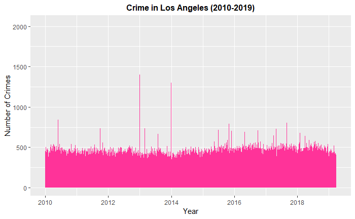

The graph plotted all the crimes occurred during 2010-2019. We can see that there are some day such as the beginning of 2013 and 2014, the number of crimes are much higher than others, and there seems to have some pattern in the graph. In order to explore if there are regular pattern for crimes, I plotted time-series plots in the following chunk.

*Use 5. Shiny App to see interactive plots.*

####3.2 Time-Series Plot  
#####3.2.1 Time Plot

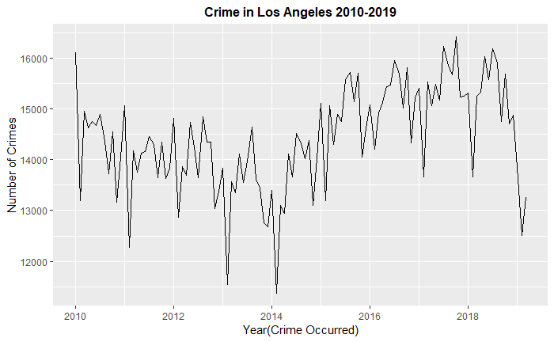

From the time plot, we can find that there is a dig in the beginning of each year which means the crime numbers decreased in the first one or two months every year. Following the dig, there is immediately an increase in the following month. The crimes happened has a decrease from 2010 to 2013, and then there was an increase in the following years from 2014 to 2018. Also, there is a huge decrease from 2018 to the beginning of 2019. According to the graph, the plot seems to have seasonality, however, it’s not very clearly in this graph.

#####3.2.2 Seasonal Plot

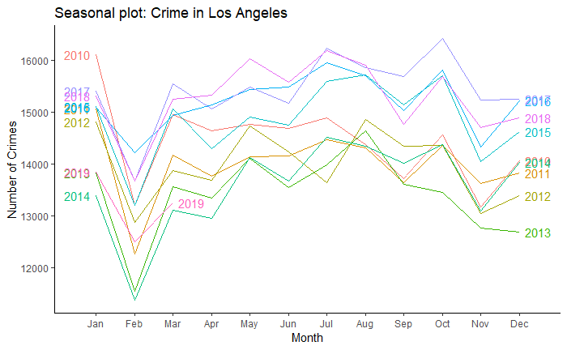

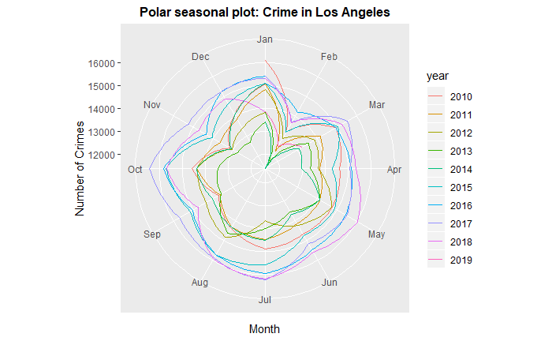

####3.3 Histograms  
#####3.3.1 Time

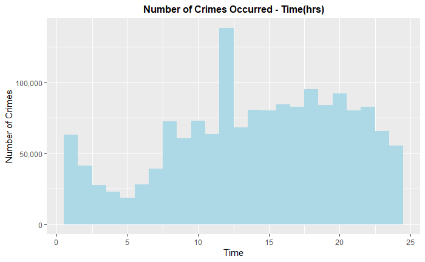

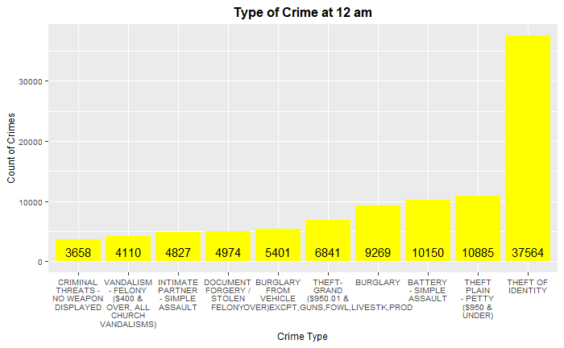

Most of the crimes occurred at **12:00 am**, the number of crimes are almost twice as many as the average of other time periods. Crimes are less likely to happen between 3 am to 7 am, with a least occurring frequency at 5 am. Crimes happened from the 1 pm to the midnight are more likely to happen than that in morning from 1 am to 11 am.

As 12am is the time that most of the crimes committed, I plotted a chart to see what are the crime types that committed most in this time period. We observed that **Theft of Identity** is the most common crime type at 12am.

*Use 5. Shiny App to see interactive plots.*

#####3.3.2 Victim Age

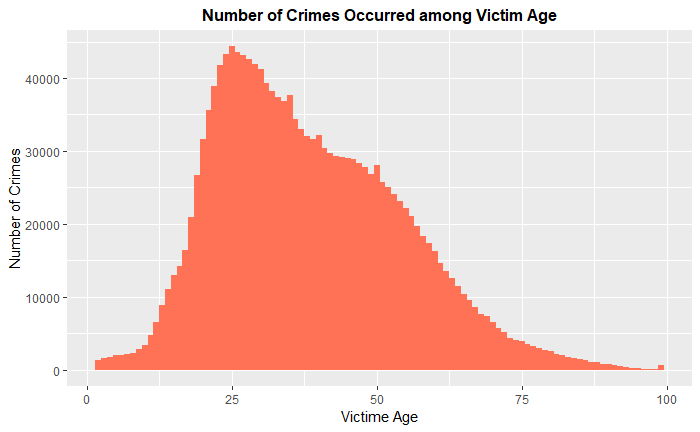

Most of the crimes happened among people from 25 to 50 years old. People aged around 25 years old are most likely to be targeted during 2010-2019. It’s a right skewed histogram, so the average age is greater than the median age.

*Use 5. Shiny App to see interactive plots.*

#####3.3.3 Age Category

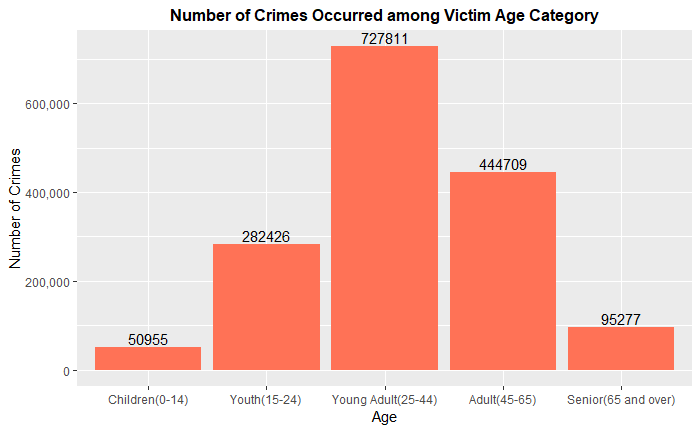

Young adults is the group that most likely to be targeted. 45.45% of the crimes occurred on young adults. Children are the least likely to be attacked group. 3.18% of the crimes occurred on children. 90.87% of the crimes occurred in Youth group, young adult group, and adult group.

####3.4 Boxplot  
#####3.4.1 Age distribution among Victime race, gender and time

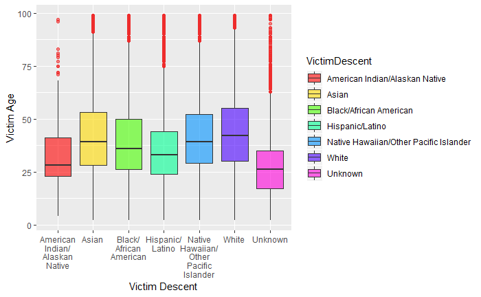

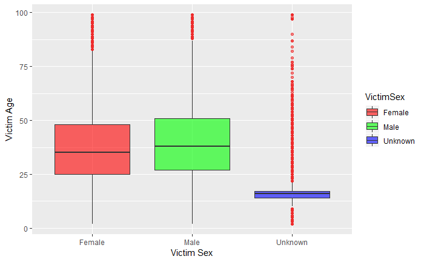

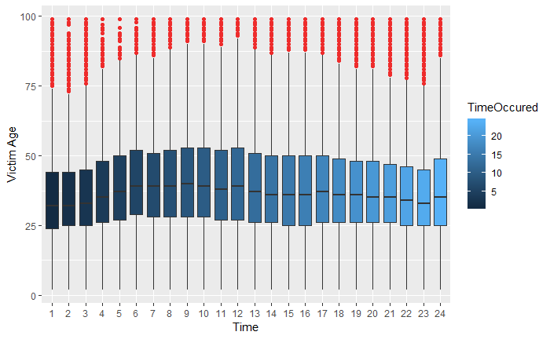

From the three boxplots above, it’s very clear that most of the crimes occurred on people aged between 25 years old to 50 years old.

From the first boxplot, we can find that the average victim age of White people is the highest among all the 7 race categories, it’s over 40 years old. The average victim age for Asian and Native Hawaiian/Other Pacific Islander, Black/African American is around 37 years old. The average victim of Hispanic/Latino people is around 35 years old, a little bit younger than the previous mentioned groups. The averge victim age of American Indian/Alaskan Native is the lowest which is around 27 years old except the Unknown group.

From the second boxplot, we can find that the average victime age of Male is a little bit higher than that of Female. However, the average age for the two groups are all near 37 years old.

From the third boxplot, we can find that the average victim age increased from 24 pm to 10 am and then has a decrease trend from 12 am to 23 pm.

####3.5 Bar chart  
#####3.5.1 Crime Distribution

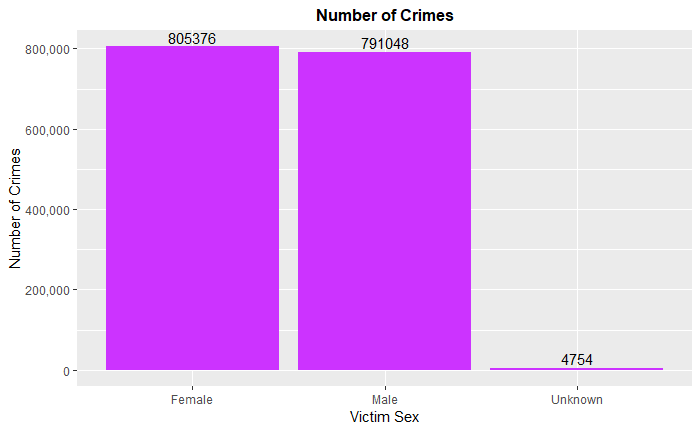

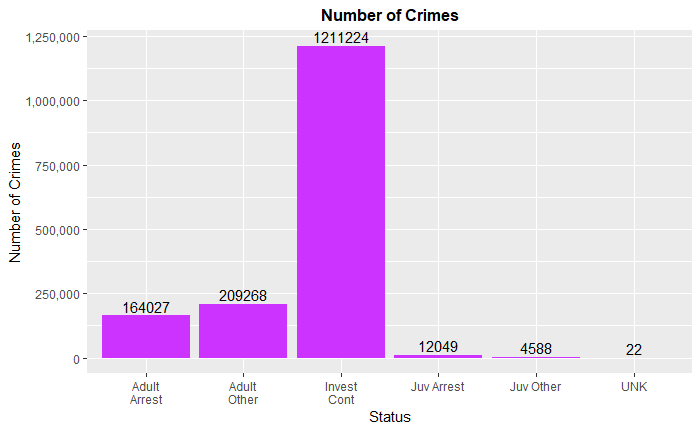

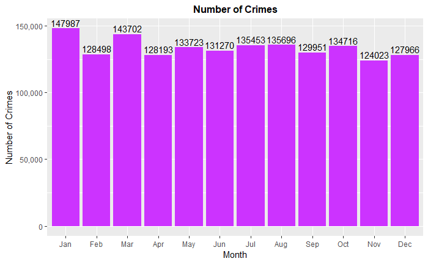

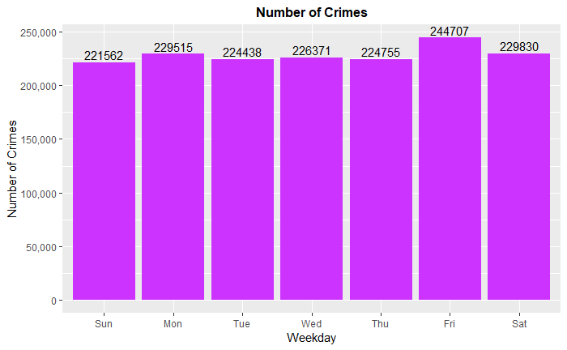

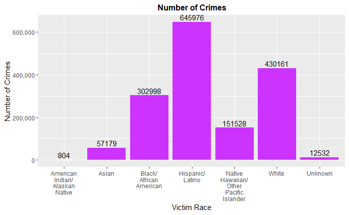

From the first graph, we can see that crimes occurred on female are more than that on male. The difference is 1.78%.

From the second graph, 75.65% of the crimes are still under investigation. 11% of the criminals were arrested, among those criminals, 93.16% are adult criminals.

From the third graph, we can find January, March have the highest crimes, November has the lowest crimes. From the fourth graph, Friday has the highest crimes. However, the difference is not very big.

From the fifth graph, we can find that among the 7 race categories, 40.34% of the crimes occurred on Hispanic/Latino. White group has a 26.87% which is the second highest group. Then Black/African American 18.92%, Native Hawaiian/Other Pacific Islander 9.46%, Asian 3.57%, American Indian/Alaskan Native 0.05%, Other races 0.78%.

*According to the 2010 Census, the racial composition of the city was:*

*White alone, not Hispanic or Latino: 26.2%*  
*Black or African American: 9.0%*  
*American Indian and Alaska Native: 1.4%*  
*Asian: 15.3%*  
*Native Hawaiian and Other Pacific Islander: 0.4%*  
*Two or more races: 3.0%*  
*Hispanic or Latino: 48.6%*

*Information retrieved from https://www.census.gov/quickfacts/fact/table/losangelescountycalifornia,ca/POP010210.*

Here is the table which compared the demographic rate with the infringement rate:

| Race | Demographic% | Infringement% |
| --- | --- | --- |
| White alone, not Hispanic or Latino | 26.2% | 26.87% |
| Black or African American | 9.0% | 18.92% |
| American Indian and Alaska Native | 1.4% | 0.05% |
| Asian | 15.3% | 3.57% |
| Native Hawaiian and Other Pacific Islander | 0.4% | 9.46% |
| Hispanic or Latino | 48.6% | 40.34% |

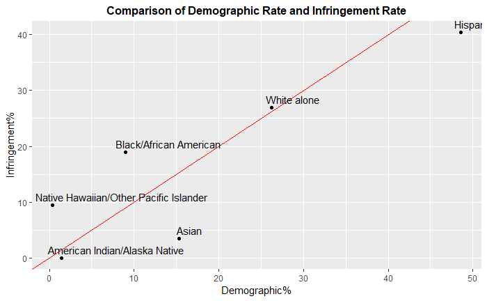

We can find that compared with the demopraphic rate, Black/African American, Native Hawaiian/other Pacific Islander, and White are more likely to be targeted as a victim compared with respective demographic rate. Asian, American Indian/Alaska Native, and Hispanic/Latino are less likely to be targeted as a victim compared with respective demographic rate.

#####3.5.2 Victim distribution by Gender - Race

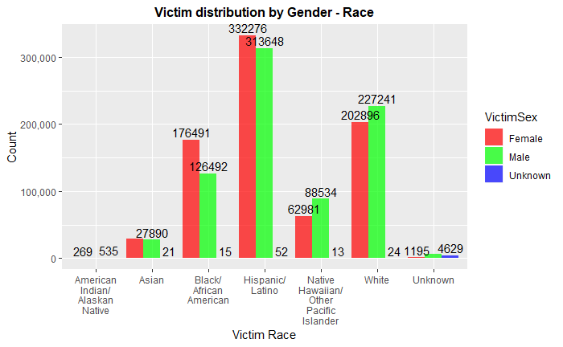

From this bar chart, we find that Female of Black/Arican American, Hispanic/Latino are more likely to be targeted as a victim compared with Male of respective race group, however, Male of Native Hawaiian/Other Pacific Islander, White, and American Indian/Alaskan Native are more likely to be targeted as a victim compared with Male of respective race group.

#####3.5.3 Victim distribution by Gender - Area

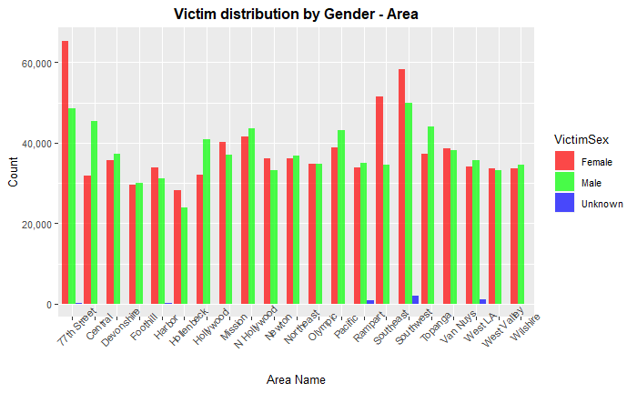

#####3.5.4 Top 10 Most Dangerous Indicators

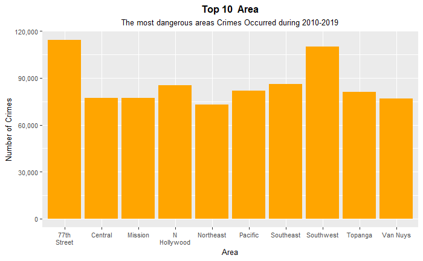

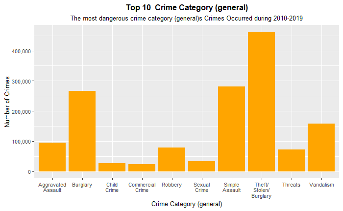

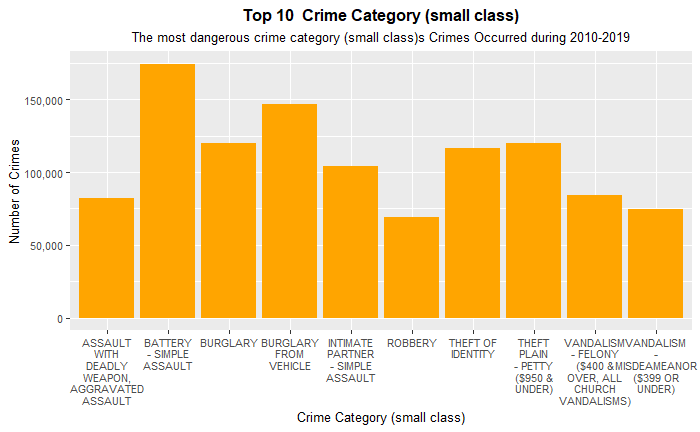

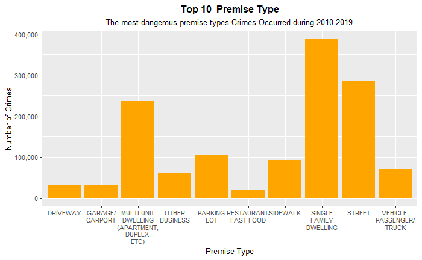

The above four bar charts represent the top 10 areas/crime categories (general)/crime categories (small class)/premise types that crimes happened mostly in the past 10 years.

Among the 21 areas, 77th Street, and Southwest are the two areas crimes would occur more than other places.

Among the 21 general crime categories, Theft/stolen/burglary is the criminal behavior most prone to take place. Child crime, sexual crime are ranked the top 9th and 8th crime category among the 21 categories which should be emphasized as well.

Among the small classes of the crimes, battery-simple assault is the No.1 crime that occurred in the past 10 years.

The top 3 places where crimes happened are single family dwelling, street, multi-unit dwelling.

#####3.5.5 Sex and Crime Description

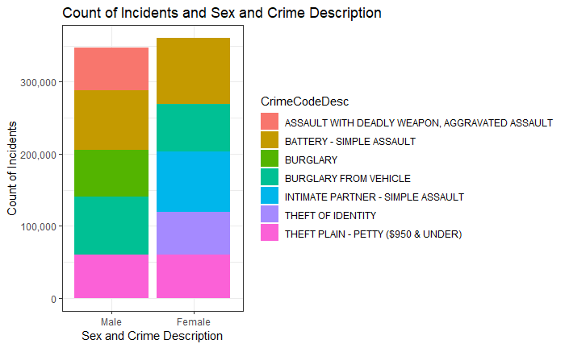

This is a graph that plotted the top 10 crime types for female and male in total.  
We observe for Female we have the Category *Intimate Partner - Simple Assault* which we do not have for Male. And Male have the category *Assault with deadly weapon, aggravated assault* which we do not have for Female. Theft Plain - Petty($950&UNDER), Battery-Simple Assault, and Burglary from vehicle are three important crime types commited for both Female and Male.

#####3.5.6 Premise Description and Crime Description

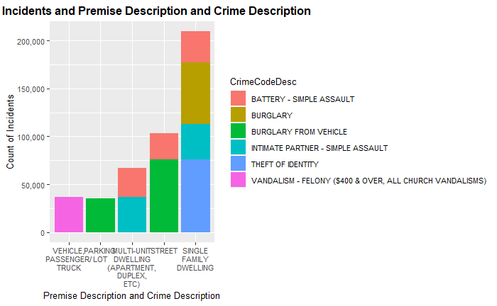

####3.6 Map  
Here is a map plotted the 21 areas in Los Angeles. 77th Street, Southwest, and Southeast which are the top 3 most dangerous areas we have discovered in the previous charts are located in the center of Los Angeles.

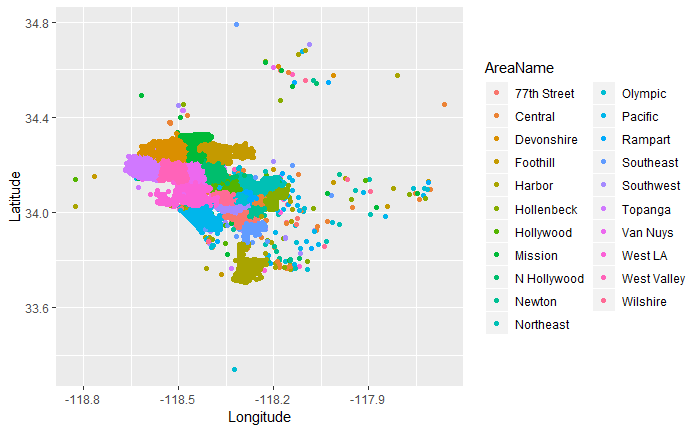

###4. Models  
The dataset has been sampled to include only 100,000 entries for the modelling. The variables with high correlations are dropped from the dataset.

####4.1 Naive Bayers  
For Naive Bayers model, only categorical variables can be used to build the model. The continuous variables were dropped. The dataset was splitted into training and validation dataset. The model was created to classify **Victim Sex**.

```
Naive Bayes Classifier for Discrete Predictors

Call:
naiveBayes.default(x = X, y = Y, laplace = laplace)

A-priori probabilities:
Y
    Female       Male    Unknown
0.50009375 0.49674379 0.00316246

Conditional probabilities:
         TimeOccured
Y                  1          2          3          4          5          6          7
  Female  0.03756749 0.02129574 0.01639672 0.01327235 0.01077285 0.01807139 0.02676965
  Male    0.04277806 0.02896326 0.01839456 0.01557625 0.01255662 0.01758933 0.02156517
  Unknown 0.03557312 0.01581028 0.03162055 0.01581028 0.01185771 0.01185771 0.03162055
         TimeOccured
Y                  8          9         10         11         12         13         14
  Female  0.04736553 0.03934213 0.04814037 0.04276645 0.09148170 0.04464107 0.05103979
  Male    0.04328133 0.03447408 0.04207348 0.03933065 0.08258681 0.04119275 0.05032713
  Unknown 0.01976285 0.03162055 0.05928854 0.04347826 0.06324111 0.05928854 0.06324111
         TimeOccured
Y                 15         16         17         18         19         20         21
  Female  0.05128974 0.05238952 0.04959008 0.05821336 0.05236453 0.05603879 0.04954009
  Male    0.04728234 0.05286865 0.05153498 0.05968797 0.05324610 0.05923503 0.05113236
  Unknown 0.06324111 0.06719368 0.04347826 0.08300395 0.05533597 0.05138340 0.05928854
         TimeOccured
Y                 22         23         24
  Female  0.04941512 0.03809238 0.03414317
  Male    0.05455460 0.04350780 0.03626069
  Unknown 0.03557312 0.02766798 0.01976285

         AreaName
Y         77th Street     Central  Devonshire    Foothill      Harbor  Hollenbeck   Hollywood
  Female  0.080508898 0.039442112 0.044441112 0.036542691 0.041641672 0.035467906 0.040316937
  Male    0.062380473 0.057599396 0.046451938 0.038550579 0.039456467 0.030271766 0.049270257
  Unknown 0.035573123 0.015810277 0.003952569 0.003952569 0.059288538 0.015810277 0.015810277
         AreaName
Y             Mission N Hollywood      Newton   Northeast     Olympic     Pacific     Rampart
  Female  0.050489902 0.050514897 0.046090782 0.045740852 0.042366527 0.047315537 0.043141372
```

[output cut: 52 more lines]

```
Y                Jan        Feb        Mar        Apr        May        Jun        Jul
  Female  0.09173165 0.07840932 0.09068186 0.08245851 0.08385823 0.08125875 0.08220856
  Male    0.09023654 0.08195773 0.09003523 0.07828384 0.08364368 0.08248616 0.08359336
  Unknown 0.09881423 0.14229249 0.10276680 0.05928854 0.06324111 0.08695652 0.08695652
         MonthOfCrime
Y                Aug        Sep        Oct        Nov        Dec
  Female  0.08198360 0.08165867 0.08628274 0.07963407 0.07983403
  Male    0.08475088 0.08097635 0.08402114 0.07873679 0.08127831
  Unknown 0.08300395 0.05533597 0.05928854 0.07905138 0.08300395

         DayOfCrime
Y                Sun        Mon        Tue        Wed        Thu        Fri        Sat
  Female  0.13579784 0.14552090 0.13797241 0.14459608 0.14509598 0.15036993 0.14064687
  Male    0.13837443 0.14209864 0.14076497 0.14124308 0.13895320 0.15309512 0.14547056
  Unknown 0.13043478 0.13043478 0.13833992 0.09881423 0.16600791 0.18181818 0.15415020
```

From the results, we can find the probabilities of victim to be a Female, Male or Unknown gender under different conditions. Take DayofCrime as an example, on Sunday, the probability the victim is a female is 13.57%, the probability the victim is a male is 13.83%, the probability of Unknown gender is 13.04%.

**Performace Evaluation**

```
Confusion Matrix and Statistics

          Reference
Prediction Female Male Unknown
   Female    5129 3186       0
   Male      4869 6740      20
   Unknown      4    8      43

Overall Statistics

               Accuracy : 0.5956
                 95% CI : (0.5888, 0.6024)
    No Information Rate : 0.5001
    P-Value [Acc > NIR] : < 0.00000000000000022

                  Kappa : 0.1964

 Mcnemar's Test P-Value : < 0.00000000000000022

Statistics by Class:

                     Class: Female Class: Male Class: Unknown
Sensitivity                 0.5128      0.6785        0.68254
Specificity                 0.6813      0.5143        0.99940
Pos Pred Value              0.6168      0.5796        0.78182
Neg Pred Value              0.5829      0.6184        0.99900
Prevalence                  0.5001      0.4967        0.00315
Detection Rate              0.2565      0.3370        0.00215
Detection Prevalence        0.4158      0.5815        0.00275
Balanced Accuracy           0.5971      0.5964        0.84097
```

####4.2 Regressions  
I converted four variables (AreaName, CrimeCategory, MonthOfCrime, DayOfCrime) that have too many levels into dummy variables for performance efficiency. The dataset was splitted into training and validation dataset by 8:2.

We do a Cross Validation using 10 folds, repeat for 5 times. Three regression models were built to compare performance in order to select the best model to predict **Victim Age**.

#####4.2.1 Ridge Regression  
The ridge regression will penalize the coefficients, those who are the least efficient in estimation will “shrink” the fastest. Naturally those who are more important will take more of the budget. As lambda is increased, the budget will “decrease”, and penalizing more. The ridge regression keeps all the features, it not allow you to select features.

```
glmnet

80001 samples
   67 predictor

No pre-processing
Resampling: Cross-Validated (10 fold, repeated 5 times)
Summary of sample sizes: 72001, 72002, 72002, 72002, 71999, 72000, ...
Resampling results across tuning parameters:

  lambda    RMSE      Rsquared   MAE
  0.000100  14.83816  0.1395412  12.09904
  0.125075  14.83816  0.1395412  12.09904
  0.250050  14.83816  0.1395412  12.09904
  0.375025  14.83828  0.1395316  12.09951
  0.500000  14.83892  0.1394832  12.10175

Tuning parameter 'alpha' was held constant at a value of 0
RMSE was used to select the optimal model using the smallest value.
The final values used for the model were alpha = 0 and lambda = 0.25005.
```

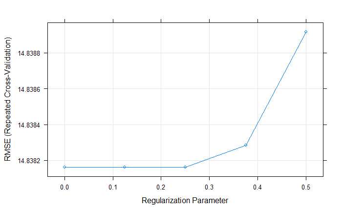

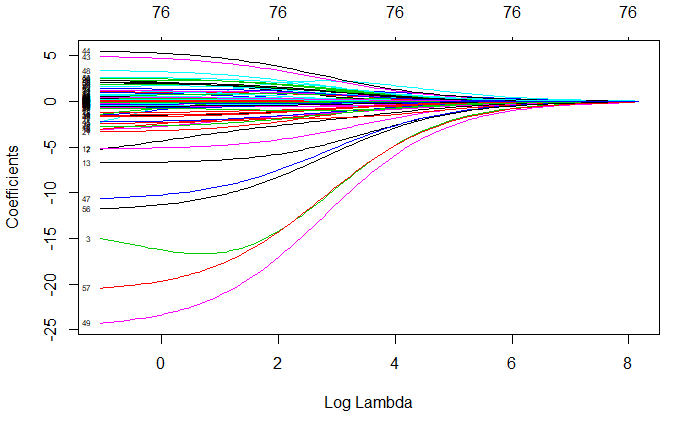

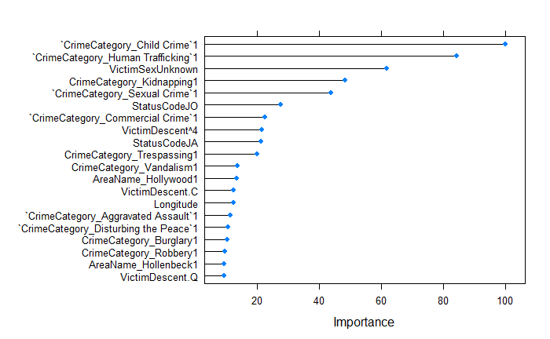